# Weibull on Pregnancy Intervals

Rob Schick

6/15/2021

## Introduction

As we’ve discussed, I’m interested in looking at the intervals between pregnancies to see if reduced health and/or increased entanglements lengthen the interval. I’m following Section 6.3 from Clark (2007) where he conducted an MLE analysis of the “time since fire” with an exponential and a Weibull, concluding there is support for a Weibull formulation.

## Pregnancy Interval Data

We start with the pregnancy data, that are gathered by Amy Knowlton at New England Aquarium. This dataset has all the pregnancies by year for each individual.

```r
pregnant <- read_csv(here::here('data-raw', '2021-02-25_years_since_pregnancy_1980-2013.csv'))%>%
  dplyr::select(!starts_with('X')) %>%
  filter(Year >=1980 & Year <= 2013) %>%
  drop_na(Pregnant) %>%
  drop_na(elapsed) %>%
  filter(elapsed >= 1) %>%
  filter(Pregnant > 0)

pregnant$Pregnant[pregnant$Pregnant == 'F'] <- '1'
pregnant$Pregnant <- as.numeric(pregnant$Pregnant)
head(pregnant)
```

```
## # A tibble: 6 x 6
##    EGNo  Year Pregnant elapsed `Last year sight… `F = first pregnancy detected`
##   <dbl> <dbl>    <dbl>   <dbl>             <dbl> <chr>
## 1  1001  1982        1       4                NA <NA>
## 2  1001  1985        1       3                NA Under elapsed, 1 is calving ye…
## 3  1001  1988        1       3                NA <NA>
## 4  1001  1991        1       3                NA <NA>
## 5  1004  1986        1       7                NA <NA>
## 6  1004  1989        1       3                NA <NA>
```

We then summrize them along the lines of how Clark does in the book (Table 6.2), which shows a peak interval of 3 years along with a long tail:

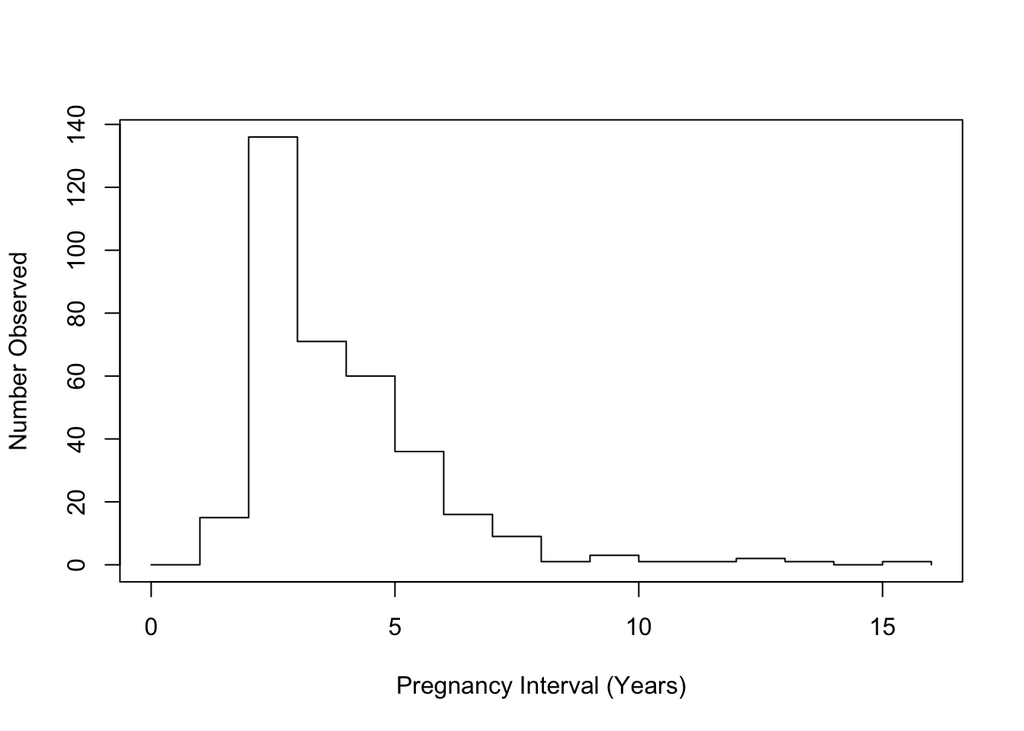

```r
pregdata <- pregnant %>%
  group_by(elapsed) %>%
  tally()
colnames(pregdata) <- c('years', 'npreg')
allyears <- seq(0, max(pregdata$years), by = 1)
npregyr <- allyears * 0
for(i in 1:length(pregdata$years)){
  npregyr[allyears[pregdata$years[i] == allyears]] <- pregdata$npreg[i]
}
plot(allyears, npregyr, type = 's', xlab = 'Pregnancy Interval (Years)', ylab = 'Number Observed')
```

Next we write down a likelihood function for the Weibull:

```r
wlik <- function(param){
  lp <- param[1]
  cp <- param[2]
  lik <- log(cp * lp^cp * pregnant$elapsed^(cp - 1)) - (lp * pregnant$elapsed)^cp
  return(-sum(lik))
}
```

Then we call `optim()`:

```r
param0 <- c(0.1, 1)
out <- optim(param0, wlik, lower = c(0.01, 0.01), upper = c(10, 10), method = "L-BFGS-B")
c(out$par[1], out$par[2])
```

```
## [1] 0.203136 2.336565
```

plot the results:

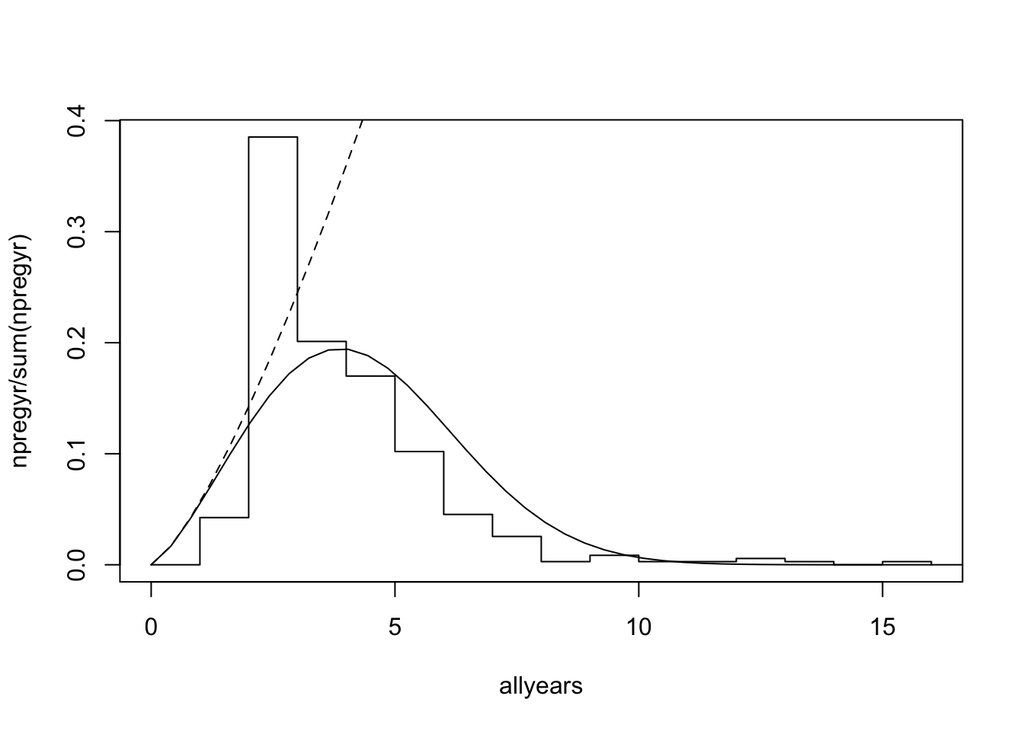

```r
lw <- out$par[1]
cw <- out$par[2]
time <- seq(0, 40, length = 100)
hazard <- cw*lw^cw*time^(cw-1)
fweib <- hazard*exp(-(lw*time)^cw)
plot(allyears, npregyr / sum(npregyr), type = 's')
lines(time, fweib)
lines(time, hazard, lty = 2)
```

…and summarize and evaluate them:

```r
lmle <- 1 / mean(pregnant$elapsed)
like <- -sum(log(lmle) - lmle*pregnant$elapsed)

likw <- out$value
dev <- 2 * (like - likw)
pr <- 1 - pchisq(dev, 1)
```

This yields a deviance of: `329.5460098`, which indicates **strong** support for the Weibull over the exponential.

## Covariates

Fair enough, but how do we incorporate covariates? Though it’s not shown above, I have calculated information about the entanglements and the health over every pregnancy interval. How then can we incorporate a link function to the covariates and which parameter do we make dependent on the covariates?

I did a bit of exploring on stack overflow, and [found this answer](https://stackoverflow.com/questions/20786249/how-to-code-a-multiparameter-log-likelihood-function-in-r) that seems pretty close. However, their likelihood function is a bit different than Jim’s as they call `dweibull` directly:

```r
LL_weibull = function(par, data, mm, inv_link_fun = function(.) .){
  P = ncol(mm) ## number of regression coefficients
  N = nrow(mm) ## number of observations
  shapes = inv_link_fun(mm %*% par[1:P]) ## shape vector (possibly transformed)
  scales = rep(par[P+1], N) ## scale vector
  -sum(dweibull(data, shape = shapes, scale = scales, log = T)) ## negative log likelihood
}
```

Herein they have the **shape** parameter depend on the covariates. Here’s my first attempt at what I would feed in for two covariates (entanglement severity and months below a pre-determined health threshold):

## Questions:

```r
wlik <- function(param){
  lp <- param[1]
  b0 <- param[2]
  b1 <- param[3]
  b2 <- param[4]
  cp <- exp(b0 + b1 * xdat[, 1] + b2 * xdat[, 2]) #seems fuzzy
  lik <- log(cp * lp^cp * pregnant$elapsed^(cp - 1)) - (lp * pregnant$elapsed)^cp
  return(-sum(lik))
}
```